# Mapping

## Geometric objects: a basis

```r
# easy fill with a fixed color
ggplot() +
  geom_sf(
    data = attributes_cologne,
    fill = "steelblue",
    color = "white"
  )
```

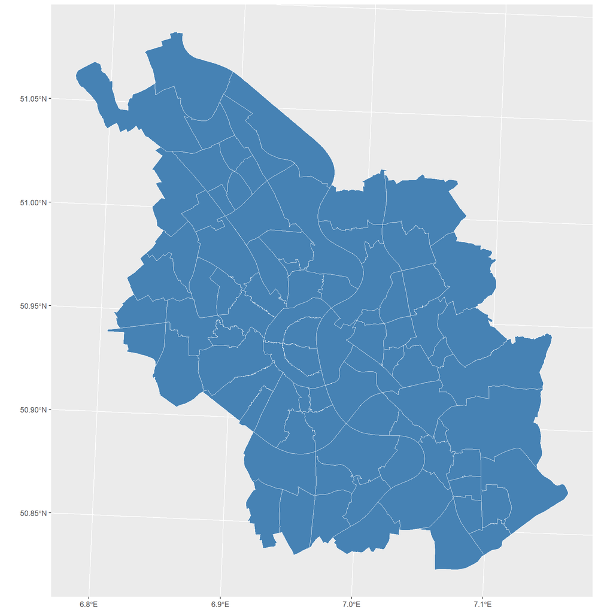

## Aesthetic mappings: `aes()`

We’ll concentrate on mapping the share of electric cars per district.

```r
ggplot() +
  geom_sf(
    data = attributes_cologne,
    # map the attribute to fill color
    aes(fill = ecar)
  ) +
  # choose a continuous color scale
  scale_fill_continuous()
```

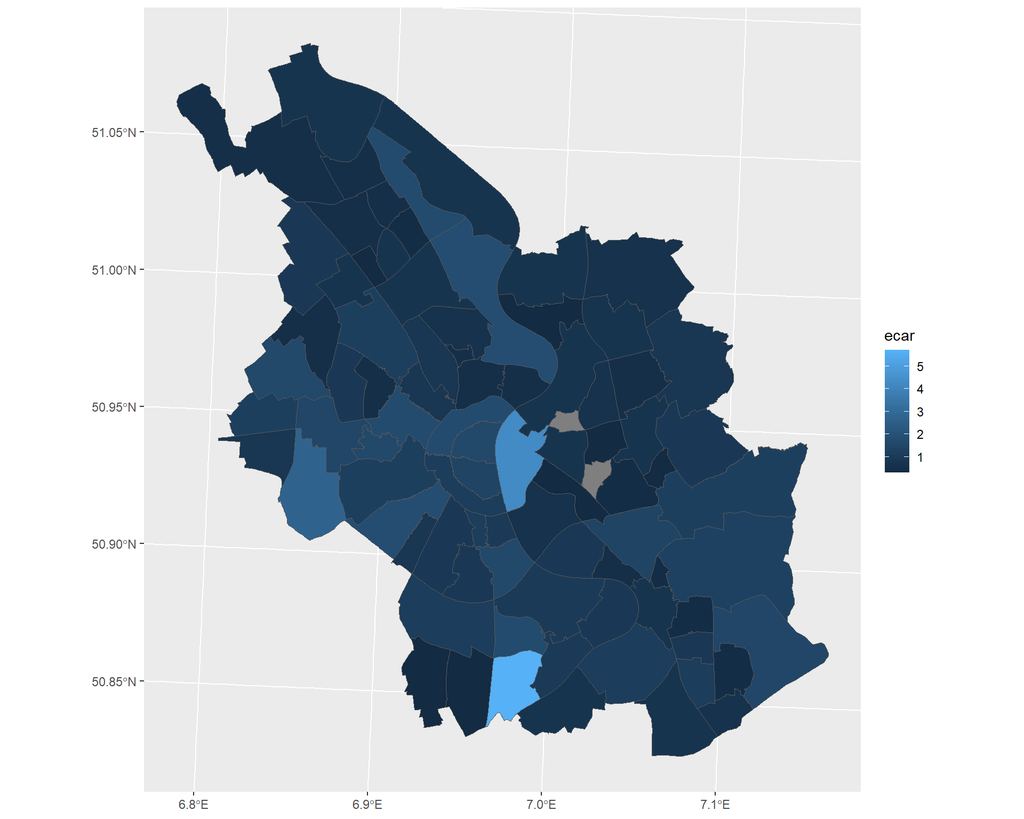

## Scales: color palette

Are you having trouble choosing the right color? Some excellent tutorials exist, e.g. by [Michael Toth](https://michaeltoth.me/a-detailed-guide-to-ggplot-colors.html).

```r
ggplot() +
  geom_sf(
    data = attributes_cologne,
    aes(fill = ecar)
  ) +
  # readable with color vision deficiencies
  scale_fill_viridis_c(option = "plasma")
```

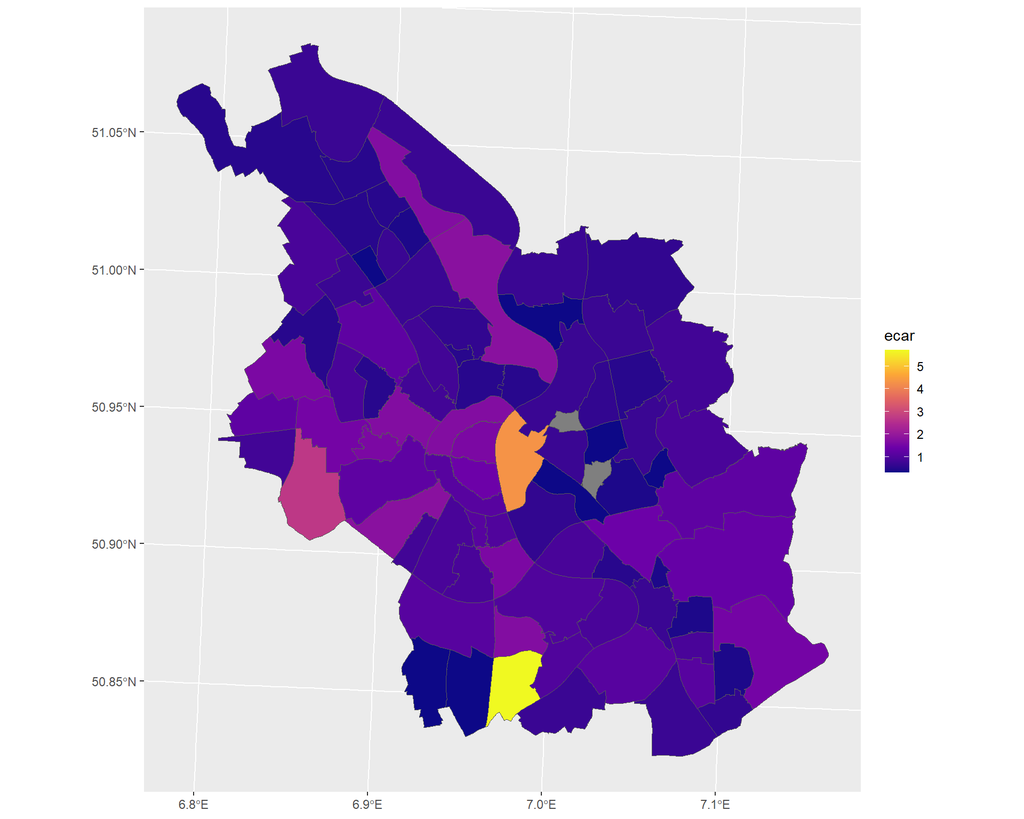

## Scales: fine-tuning

```r
ggplot() +
  geom_sf(
    data = attributes_cologne,
    aes(fill = ecar),
    # remove district borders
    color = NA
  ) +
  scale_fill_viridis_c(
    option = "plasma",
    # flip the scale direction
    direction = -1
  )
```

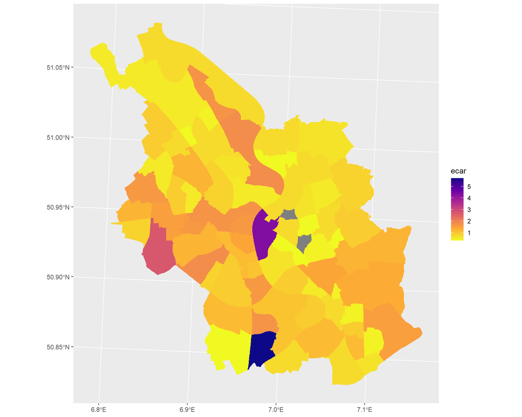

## Save and reuse

Maps produced with `ggplot2` are standard `R` objects (they are lists). We can assign them to reuse, plot later, and keep adding layers.

```r
cologne_map <-
  ggplot() +
  geom_sf(
    data = attributes_cologne,
    aes(fill = ecar),
    color = NA
  )

cologne_map_better <-
  cologne_map +
  scale_fill_viridis_c(
    option = "plasma",
    direction = -1
  )
```

## Save and reuse

Furthermore, `ggsave()` automatically detects the file format from the extension. You can also control height, width, and dpi — particularly useful for publication-ready graphics.

```r
ggsave("cologne_map_better.png", cologne_map_better, dpi = 300)
```

## Geometric objects: point layers

Point data loaded with `sf::read_sf()` is displayed with the same `geom_sf()` — `ggplot2` detects the geometry type automatically.

Key aesthetics for point layers:

| Argument | What it controls | Fixed or mapped? |
| --- | --- | --- |
| `color` | point color | both |
| `size` | point diameter | both |
| `alpha` | transparency (0–1) | both |
| `shape` | point shape (0–25) | both |

## Show some points

```r
ggplot() +
  geom_sf(
    data  = charger_cologne,
    color = "black",
    size  = 2,
    alpha = .6
  )
```

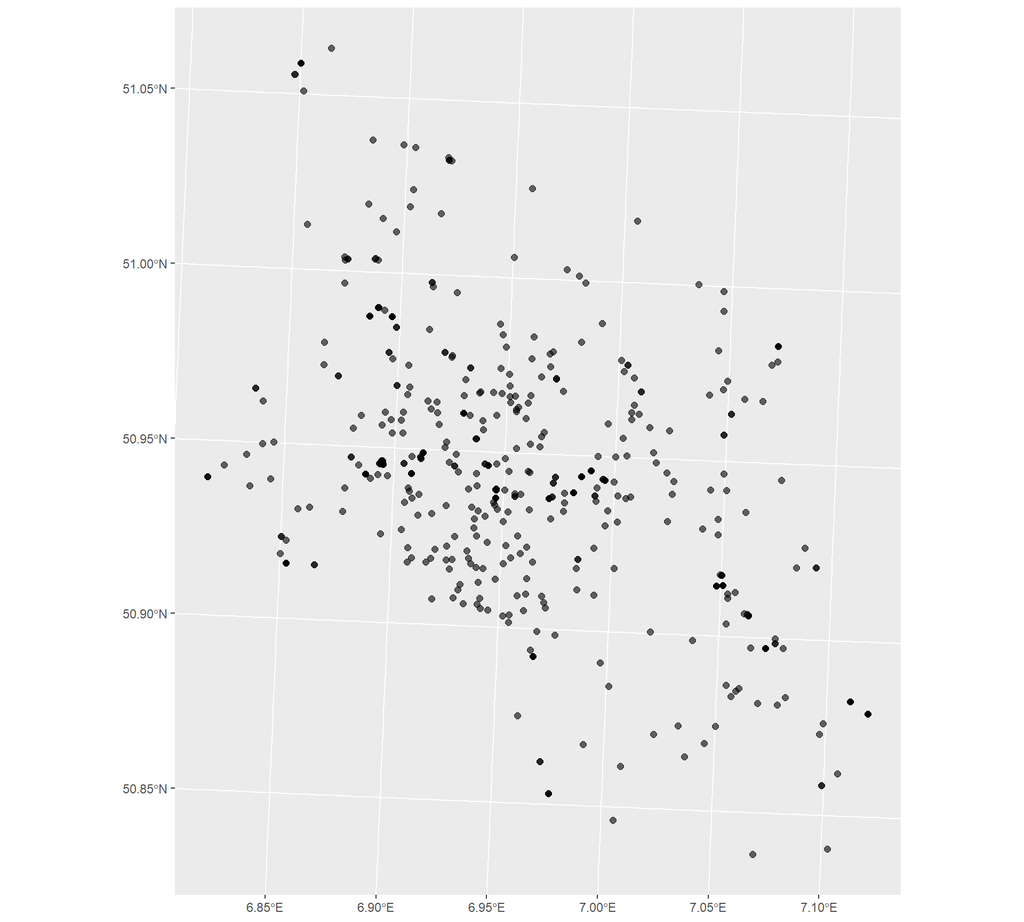

## Geometric objects: combining layers

`geom_sf()` stacks layers in order — add the point layer **after** the polygon layer so it appears on top.

```r
ggplot() +
  # 1st layer: polygon — e-car share
  geom_sf(
    data = attributes_cologne,
    aes(fill = ecar),
    color = NA
  ) +
  scale_fill_viridis_c(
    option = "plasma",
    direction = -1
  ) +
  # 2nd layer: points
  geom_sf(
    data = charger_cologne,
    # wrap color in aes(): force a legend entry
    aes(color = "Charging Stations"),
    size = 2
  ) +
  scale_color_manual(
    name   = NULL,
    values = c("Charging Stations" = "black")
  )
```

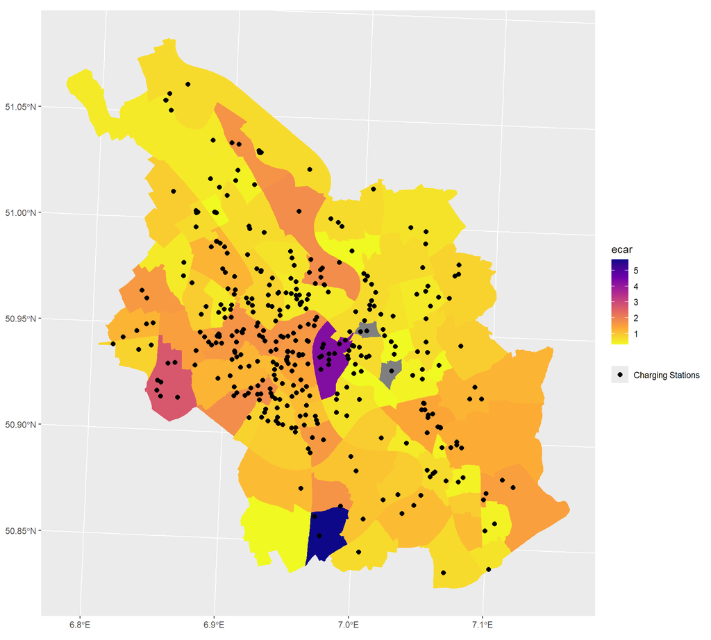

## Scales: legends

You can handle everything concerning the legend within the `scale_*`.

```r
ggplot() +
  geom_sf(
    data = attributes_cologne,
    aes(fill = ecar),
    color = NA
  ) +
  scale_fill_viridis_c(
    option = "plasma",
    direction = -1,
    # add a legend title
    name = "E-Car Share",
    # adjust legend display
    guide = guide_legend(
      # turn it horizontal
      direction = "horizontal",
      # put labels under the legend bar
      label.position = "bottom"
    )
  )

# check the help file for more options: ?guide_legend
```

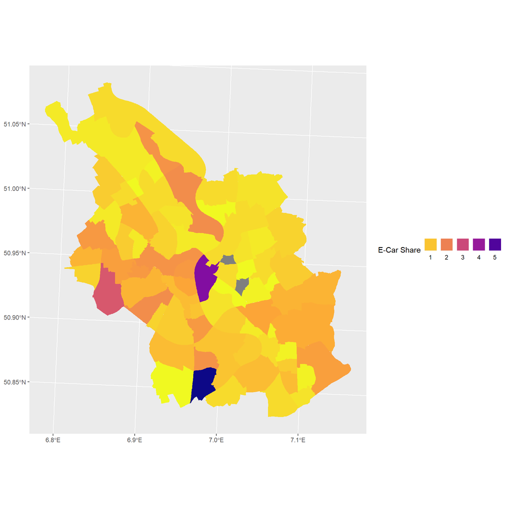

## Themes: get rid of everything?!

The `theme` controls all non-data displays. Instead of removing everything, try the built-in themes.

```r
# use the cologne_map object as base
cologne_map +
  # remove all non-data ink
  theme_void()


# ... or try another built-in theme:
# theme_bw()
# theme_gray()
# theme_light()

# see all options: ?theme
```

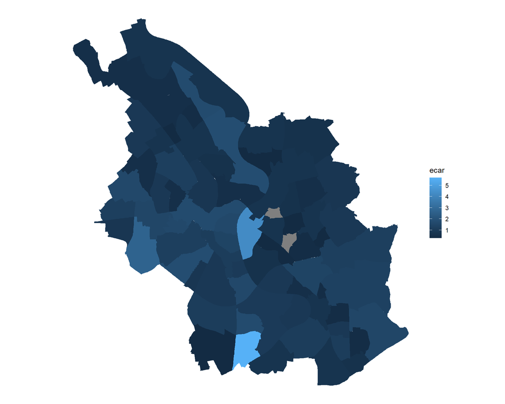

## Themes: build your own `theme`

```r
cologne_map +
  theme_void() +
  theme(
    # bold all text elements
    title = element_text(face = "bold"),
    # move legend to bottom
    legend.position = "bottom",
    # change background color
    panel.background =
      element_rect(fill = "lightgrey")
  )
```

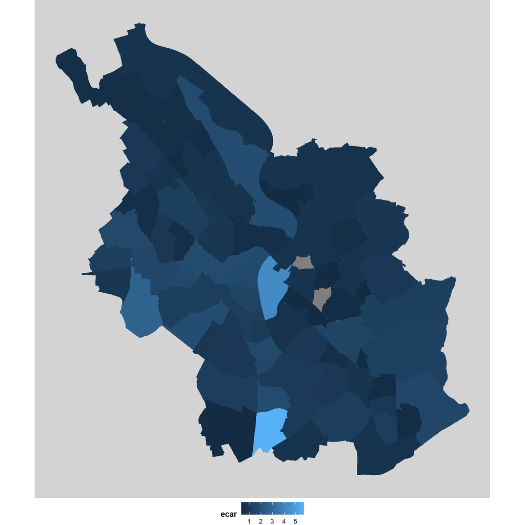

## Labels & sources: adding `labs`

Always include and cite your data sources. `labs()` lets you add titles, subtitles, and captions directly to the map.

```r
cologne_map +
  theme_void() +
  labs(
    title    = "Electric Cars in Cologne",
    subtitle = "Share of registered electric vehicles per district",
    caption  = "© Stadt Köln; Bundesnetzagentur"
  )
```

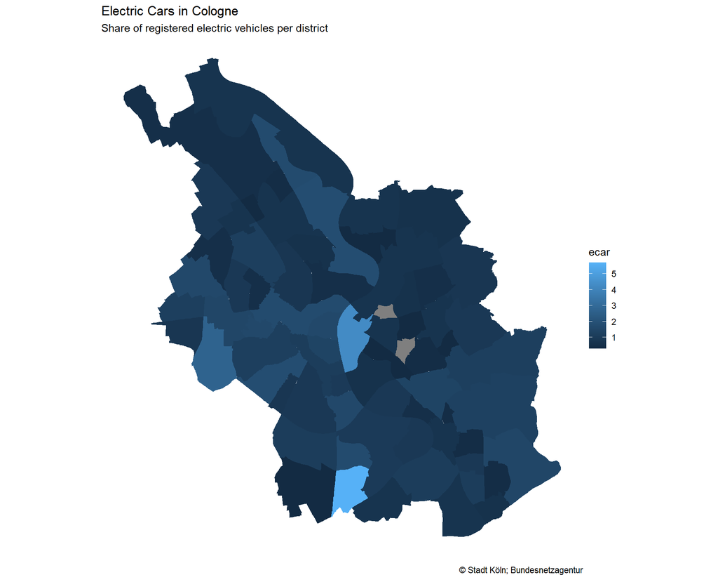

## Exercise 3_1: Basic Maps💪

[Exercise](https://denabel.github.io/BIGSSS_geo_2026/exercises/3_1_Mapping.html)

## To be continued…

Our code has already grown. Without going into too much detail, the following slides showcase some more changes you can make to your maps.

**A map is never finished until you decide not to work on it anymore.**

## Facet maps: data preparation

`facet_wrap()` creates small multiples — one panel per group. The data must be in **long format** first.

```r
# pivot the six party columns into one long column
cologne_parties <-
  attributes_cologne |>
  tidyr::pivot_longer(
    cols      = c(cdu, spd, greens, afd, left, fdp),
    # new column holding the party name
    names_to  = "party",
    # new column holding the vote share value
    values_to = "vote_share"
  )

# each district now appears six times — once per party
cologne_parties |>
  sf::st_drop_geometry() |>
  dplyr::select(id, party, vote_share) |>
  head(8)
```

```
# A tibble: 8 × 3
     id party  vote_share
  <dbl> <chr>       <dbl>
1   202 cdu          32.6
2   202 spd          12.1
3   202 greens       26.7
4   202 afd           5.5
5   202 left          2.9
6   202 fdp          12.9
7   201 cdu          19
8   201 spd          14.7
```

## Facet maps

```r
ggplot() +
  geom_sf(
    data  = cologne_parties,
    aes(fill = vote_share),
    color = NA
  ) +
  scale_fill_viridis_c(
    option    = "plasma",
    direction = -1,
    name      = "Vote Share"
  ) +
  # one panel per party
  facet_wrap(~ party, ncol = 3) +
  theme_void() +
  theme(legend.position = "bottom") +
  labs(
    title   = "EU Election 2019 in Cologne",
    caption = "© Stadt Köln"
  )
```

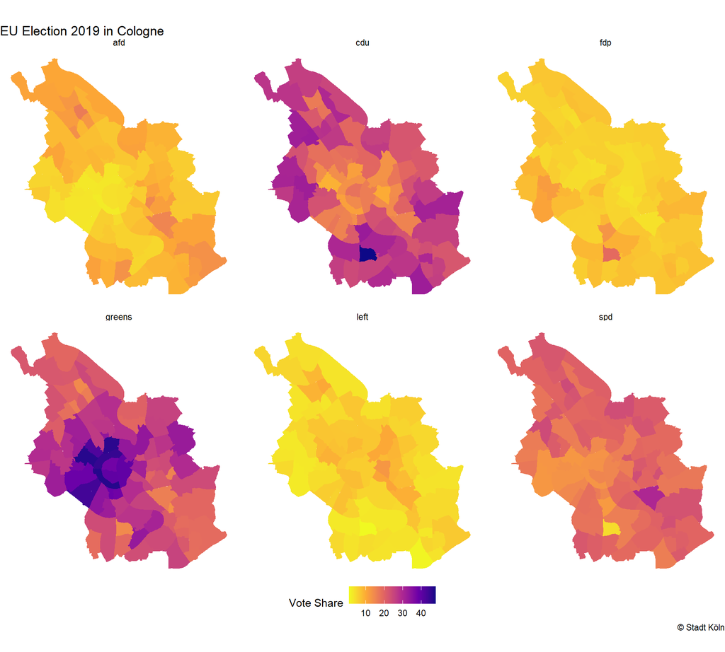

## Animated maps

`gganimate` extends `ggplot2` with animation — add one transition layer to any existing map.

Key transition functions:

| Function | Use case |
| --- | --- |
| `transition_manual(var)` | Step through a categorical variable (e.g. party, month name) |
| `transition_states(var)` | Smooth transitions between groups |
| `transition_time(var)` | Animate along a numeric time variable |

## Animated maps

```r
library(gganimate)
library(gifski)

# reuse cologne_parties from the facets slide
vote_animation <-
  ggplot() +
  geom_sf(
    data  = cologne_parties,
    aes(fill = vote_share),
    color = NA
  ) +
  scale_fill_viridis_c(
    option    = "plasma",
    direction = -1,
    name      = "Vote Share"
  ) +
  theme_void() +
  theme(legend.position = "bottom") +
  labs(
    # {current_frame} is replaced by the active frame value
    title   = "EU Election 2019 in Cologne — {current_frame}",
    caption = "© Stadt Köln"
  ) +
  # one frame per party, no interpolation between categories
  gganimate::transition_manual(party)

# render (nframes = number of parties, fps = speed)
gganimate::animate(vote_animation, nframes = 6, fps = 1)

# save as GIF
gganimate::anim_save("vote_animation.gif")
```

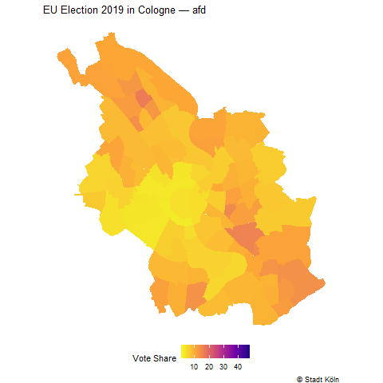

## Adding map labels: data preparation

To add labels, we need regular X/Y columns — not geometries. We use `sf::st_centroid()` to find polygon centers, then `sf::st_coordinates()` to extract the coordinates.

```r
# compute polygon centroids and pull X/Y into plain columns
precinct_labels <-
  attributes_cologne |>
  sf::st_centroid() |>
  dplyr::mutate(
    X = sf::st_coordinates(geometry)[, "X"],
    Y = sf::st_coordinates(geometry)[, "Y"]
  )

precinct_labels |> dplyr::select(name, X, Y)
```

```
Simple feature collection with 86 features and 3 fields
Geometry type: POINT
Dimension:     XY
Bounding box:  xmin: 4098358 ymin: 3085516 xmax: 4118753 ymax: 3110470
Projected CRS: ETRS89-extended / LAEA Europe
# A tibble: 86 × 4
   name                     X        Y          geometry
   <chr>                <dbl>    <dbl>       <POINT [m]>
 1 202 / Marienburg  4108185. 3091764. (4108185 3091764)
 2 201 / Bayenthal   4107906. 3093194. (4107906 3093194)
 3 209 / Weiß        4112436. 3089782. (4112436 3089782)
 4 207 / Hahnwald    4108645. 3088915. (4108645 3088915)
 5 213 / Meschenich  4104993. 3087128. (4104993 3087128)
 6 212 / Immendorf   4106698. 3086747. (4106698 3086747)
 7 211 / Godorf      4108482. 3086941. (4108482 3086941)
 8 308 / Lövenich    4098358. 3097866. (4098358 3097866)
 9 307 / Weiden      4098530. 3096392. (4098530 3096392)
10 306 / Junkersdorf 4100290. 3094742. (4100290 3094742)
# ℹ 76 more rows
```

## `geom_text` and `geom_label`

`geom_text()` adds plain text; `geom_label()` adds a text box with a background which is useful when the map underneath is busy.

```r
# geom_text: clean, no background
cologne_map +
  theme_void() +
  geom_text(
    data     = precinct_labels,
    aes(x = X, y = Y, label = name),
    size     = 2.5,
    color    = "white",
    fontface = "bold"
  )

# geom_label: text box with background
cologne_map +
  theme_void() +
  geom_label(
    data  = precinct_labels,
    aes(x = X, y = Y, label = name),
    size  = 2.5,
    color    = "white",
    alpha = .8 #box background
  )
```

[output not shown]

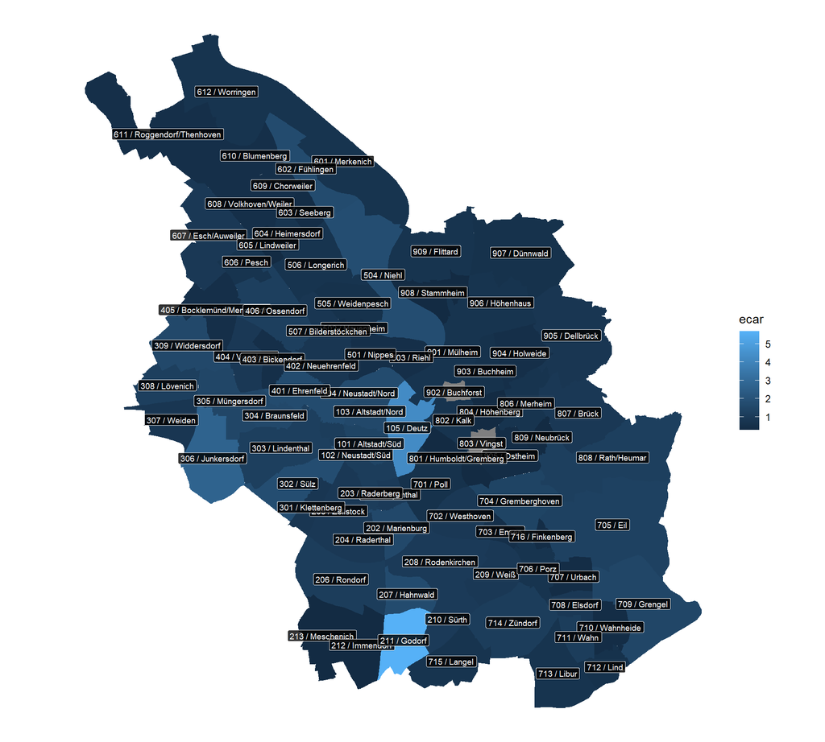

## Interactive maps: `mapview`

`mapview` is the fastest route to an interactive map — one function call, no extra setup.

```r
library(mapview)

# one line: instant interactive map
mapview::mapview(
  attributes_cologne,
  zcol       = "ecar",        # column to map
  layer.name = "E-Car Share"  # legend title
)
```

Features out of the box:

- Pan, zoom, click on features
- Basemap tiles automatically added
- Works with any `sf` object

[interactive chart not shown]

## Interactive maps: `leaflet`

`leaflet` gives you full control over basemaps, popups, and color scales.

```r
library(leaflet)

# leaflet requires WGS84 (EPSG:4326)
attributes_wgs84 <-
  attributes_cologne |>
  sf::st_transform(crs = 4326)

# define a color palette function
pal <- leaflet::colorNumeric(palette = "plasma", domain = attributes_wgs84$ecar)

leaflet_map <-
  leaflet::leaflet(attributes_wgs84) |>
  leaflet::addTiles() |>                    # add basemap
  leaflet::addPolygons(
    fillColor   = ~pal(ecar),              # map color to ecar
    fillOpacity = 0.7,
    color       = "white",
    weight      = 1,
    popup       = ~paste("E-Car Share:", round(ecar, 3))  # click popup
  ) |>
  leaflet::addLegend(
    pal    = pal,
    values = ~ecar,
    title  = "E-Car Share"
  )

# save as html map
mapview::mapshot(leaflet_map, url = "leaflet_map.html")
```

## `ggplot2` and raster data

You can also use `ggplot2` to create maps with raster data. The easiest way is using the `tidyterra` package.

```r
ggplot() +
  tidyterra::geom_spatraster(
    data = immigrants_cologne,
    aes(fill = immigrants_cologne)
  ) +
  # set NA values to transparent
  scale_fill_viridis_c(
    option = "magma",
    na.value = "transparent",
    name = "Share of\nImmigrants"
  ) +
  theme_void()
```

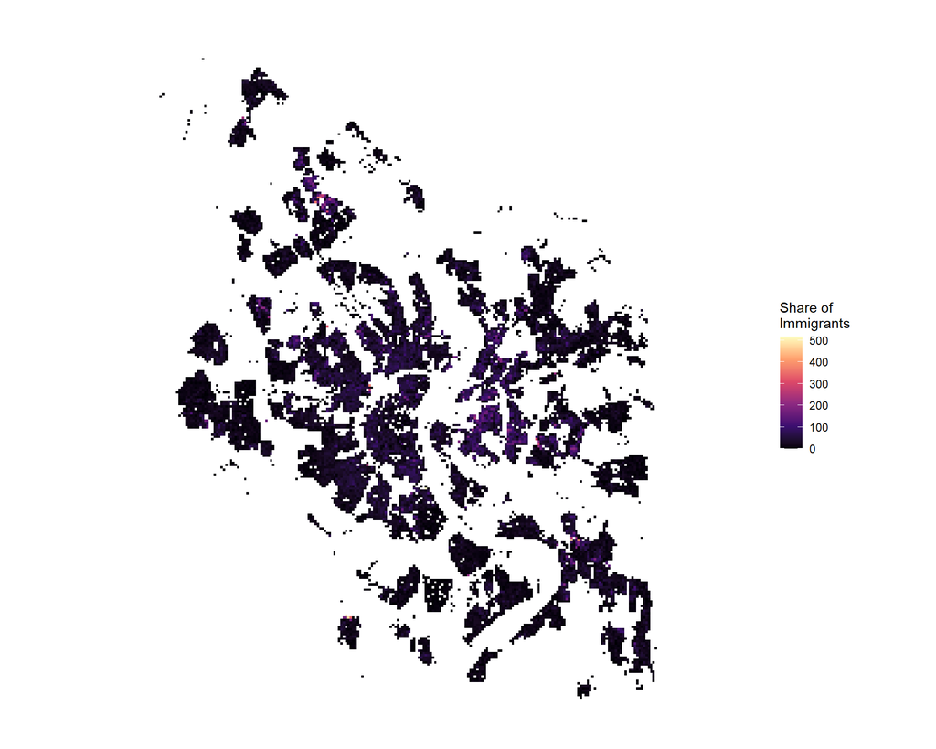

## Add-ons with `ggspatial`

Typical cartographic elements are not included in `ggplot2` — like a **compass** or **scale bar**.

The good thing: elements of the package `ggspatial` can be included as regular `ggplot2` layers.

Check out [paleolimbot.github.io/ggspatial](https://paleolimbot.github.io/ggspatial/).

## Scale bar & north arrow

```r
cologne_map +
  theme_void() +
  labs(
    title   = "Electric Cars in Cologne",
    caption = "© Stadt Köln; Bundesnetzagentur"
  ) +
  # scale bar: bottom-right
  ggspatial::annotation_scale(
    location = "br"
  ) +
  # north arrow: top-right
  ggspatial::annotation_north_arrow(
    location = "tr",
    style = ggspatial::north_arrow_minimal()
  )
```

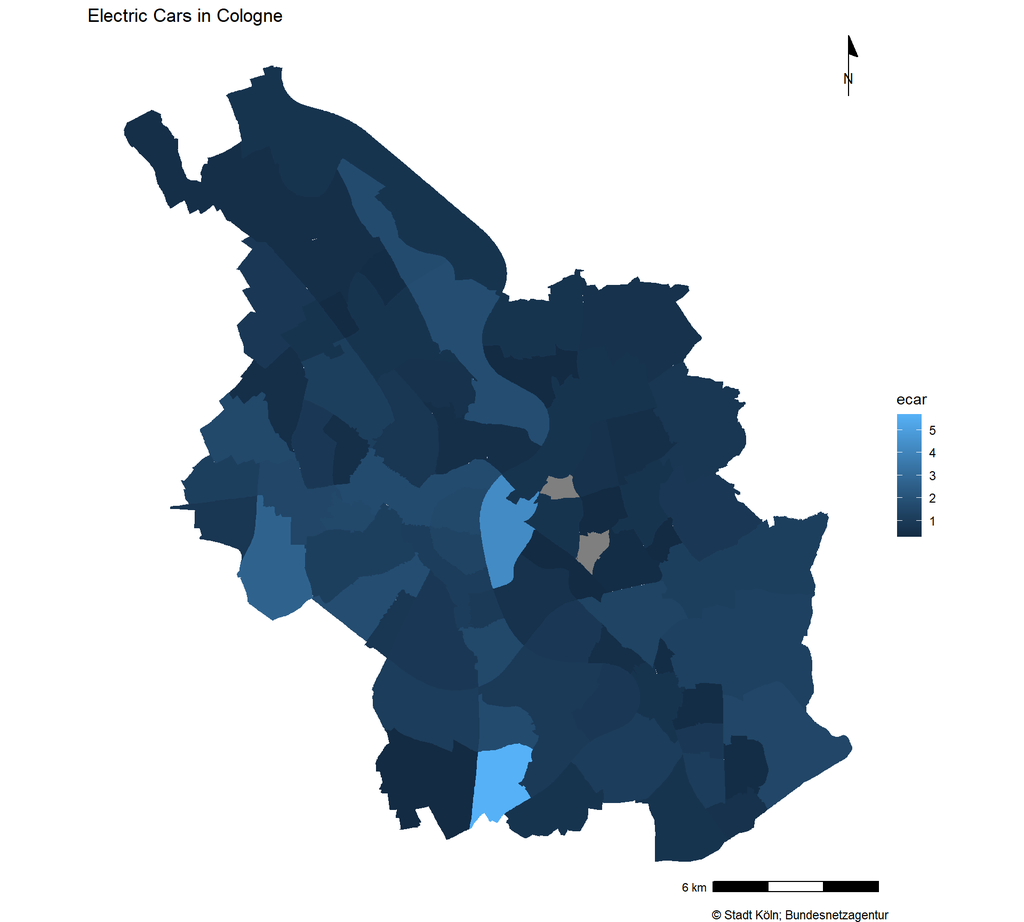

## Note On Mapping Responsibly

**In the best cases**, maps are easy to understand and an excellent way to transport (scientific) messages.

**In the worst cases**, they simplify (spurious) correlations and draw a dramatic picture of the world.

**Maps can shape narratives**

- Decisions on which projection you use (remember the `true size` projector?),
- The segment of the world you choose,
- And the colors and styles you add have a strong influence.

Example: [Kenneth Field’s blog post](https://www.esri.com/arcgis-blog/products/product/mapping/mapping-coronavirus-responsibly/)

## Color vision deficiencies

The `colorBlindness` package simulates how your map looks for people with different types of color vision deficiency.

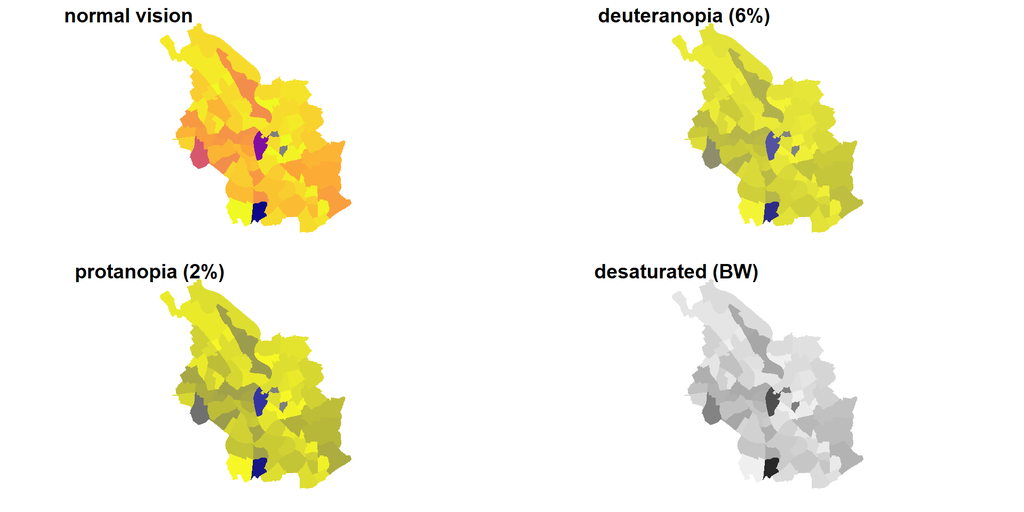

Created with the package [`colorBlindness`](https://cran.r-project.org/web/packages/colorBlindness/index.html). Viridis palettes are designed to be perceptually uniform and accessible for color vision deficiencies.

## `tmap`: An Alternative

[`tmap`](https://r-tmap.github.io/tmap/) is another popular package for thematic mapping in R:

- Very intuitive — makes ‘good’ cartographic decisions automatically
- Syntax based on the same *grammar of graphics* as `ggplot2`
- Built-in support for **interactive maps** (`tmap_mode("view")`)
- Built-in support for **animated maps** (`tmap_animation()`)
- Ideal for quick exploratory mapping

When you need interactivity or animation without additional packages, `tmap` is a great choice.

## `tmap`: Quick Syntax Overview

```r
library(tmap)

# define spatial object, then choose a display element
tm_shape(attributes_cologne) +
  tm_polygons(
    fill = "ecar",
    fill.legend = tm_legend(title = "E-Car Share")
  )

# switch to interactive mode
tmap_mode("view")
tm_shape(attributes_cologne) + tm_polygons("ecar")

# switch back to static
tmap_mode("plot")

# save options
# tmap_save(my_map, filename = "map.png")
# tmap_save(my_map, filename = "map.html")  # interactive
```

For learning more: [r-tmap.github.io/tmap](https://r-tmap.github.io/tmap/)

## Exercise 3_2: Fun with Maps💪

[Exercise](https://denabel.github.io/BIGSSS_geo_2026/exercises/3_2_Fun_with_Maps.html)